# Full analysis — Mother-child study

## Loading packages and data

```r
library(tidyverse)
library(here)
library(ggpubr)

donnees <- read_tsv(here("data/etude_mere_enfant.csv"), na = c("", "NA", "f"))
donnees <- donnees %>%
  mutate(`CMV cord` = as.numeric(`CMV cord`),
         Howmanylivingchildrendoyouhave = as.numeric(Howmanylivingchildrendoyouhave))
```

## 1️⃣ HIV, inflammation (sCD14) and intestinal damage (IFABP)

### sCD14 — inflammation marker

```r
t.test(`sCD14 [ng/ml]` ~ `HIV STATUS`, data = donnees)
```

```
##
##  Welch Two Sample t-test
##
## data:  sCD14 [ng/ml] by HIV STATUS
## t = -5.2168, df = 138.03, p-value = 6.523e-07
## alternative hypothesis: true difference in means between group Negative and group Positive is not equal to 0
## 95 percent confidence interval:
##  -290.7717 -130.9343
## sample estimates:
## mean in group Negative mean in group Positive
##               1095.514               1306.367
```

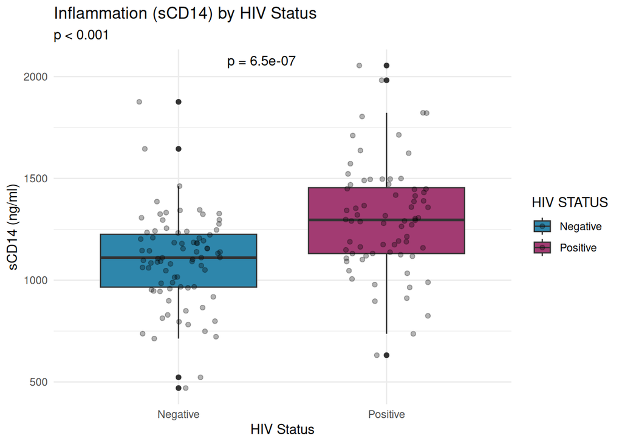

```r
ggplot(donnees, aes(x = `HIV STATUS`, y = `sCD14 [ng/ml]`, fill = `HIV STATUS`)) +
  geom_boxplot() +
  geom_jitter(alpha = 0.3, width = 0.2) +
  stat_compare_means(method = "t.test", label.x = 1.3, label = "p.format") +
  labs(title = "Inflammation (sCD14) by HIV Status",
       subtitle = "p < 0.001",
       x = "HIV Status", y = "sCD14 (ng/ml)") +
  scale_fill_manual(values = c("Negative" = "#2E86AB", "Positive" = "#A23B72")) +
  theme_minimal()
```

### IFABP — intestinal permeability marker

```r
wilcox.test(`IFABP [pg/ml]` ~ `HIV STATUS`, data = donnees)
```

```
##
##  Wilcoxon rank sum test with continuity correction
##
## data:  IFABP [pg/ml] by HIV STATUS
## W = 2134, p-value = 0.005942
## alternative hypothesis: true location shift is not equal to 0
```

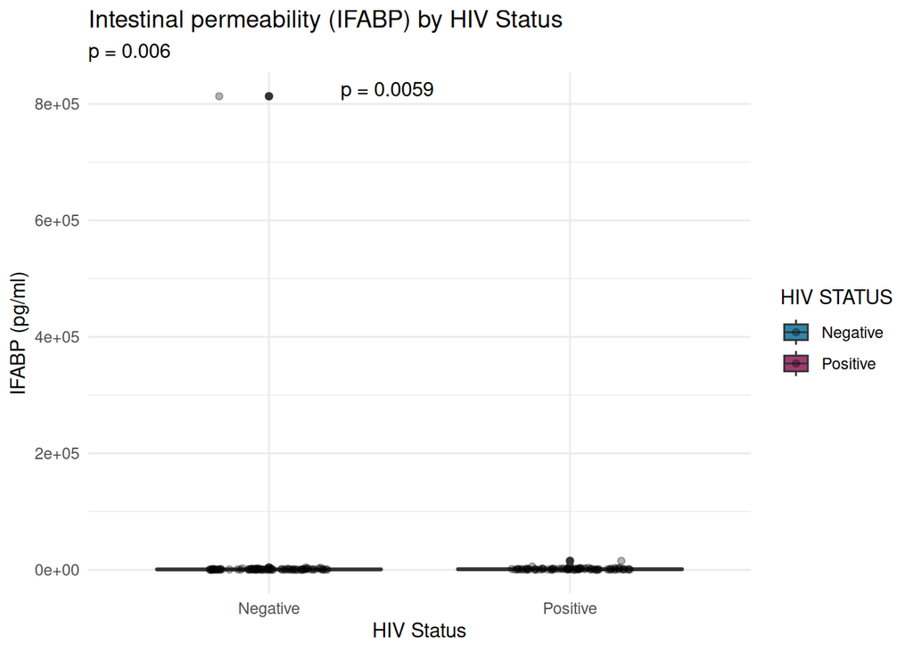

```r
ggplot(donnees, aes(x = `HIV STATUS`, y = `IFABP [pg/ml]`, fill = `HIV STATUS`)) +
  geom_boxplot() +
  geom_jitter(alpha = 0.3, width = 0.2) +
  stat_compare_means(method = "wilcox.test", label.x = 1.3, label = "p.format") +
  labs(title = "Intestinal permeability (IFABP) by HIV Status",
       subtitle = "p = 0.006",
       x = "HIV Status", y = "IFABP (pg/ml)") +
  scale_fill_manual(values = c("Negative" = "#2E86AB", "Positive" = "#A23B72")) +
  theme_minimal()
```

### Cord sCD14

```r
t.test(`cord sCD14 [ng/ml]` ~ `HIV STATUS`, data = donnees)
```

```
##
##  Welch Two Sample t-test
##
## data:  cord sCD14 [ng/ml] by HIV STATUS
## t = 0.37784, df = 93.315, p-value = 0.7064
## alternative hypothesis: true difference in means between group Negative and group Positive is not equal to 0
## 95 percent confidence interval:
##  -23.03710  33.86407
## sample estimates:
## mean in group Negative mean in group Positive
##               61.62761               56.21413
```

> **Finding:** HIV is associated with **higher systemic inflammation** (sCD14: p < 0.001) but **not** with cord inflammation (p = 0.71). IFABP (intestinal) shows a significant median difference (p = 0.006).

## 2️⃣ Which antibody transfers best from mother to cord?

```r
virus_ratio <- c("ratio CMV" = "CMV", "ratio RSV" = "RSV",
                 "ratio ENTERO" = "Enterovirus", "ratio TT" = "TT")

for (nom in names(virus_ratio)) {
  vals <- donnees[[nom]]
  efficaces <- sum(vals > 1, na.rm = TRUE)
  total <- sum(!is.na(vals))
  cat(sprintf("\n=== %s ===\n", virus_ratio[nom]))
  cat(sprintf("Median = %.3f  |  Mean = %.3f\n", median(vals, na.rm = TRUE), mean(vals, na.rm = TRUE)))
  cat(sprintf("Efficient transfer (>1) : %d / %d (%.1f%%)\n", efficaces, total, 100*efficaces/total))
}
```

```
##
## === CMV ===
## Median = 1.179  |  Mean = 3.788
## Efficient transfer (>1) : 86 / 152 (56.6%)
##
## === RSV ===
## Median = 2.471  |  Mean = 2.625
## Efficient transfer (>1) : 152 / 152 (100.0%)
##
## === Enterovirus ===
## Median = 2.303  |  Mean = 4.235
## Efficient transfer (>1) : 127 / 152 (83.6%)
##
## === TT ===
## Median = 0.673  |  Mean = 7.808
## Efficient transfer (>1) : 34 / 152 (22.4%)
```

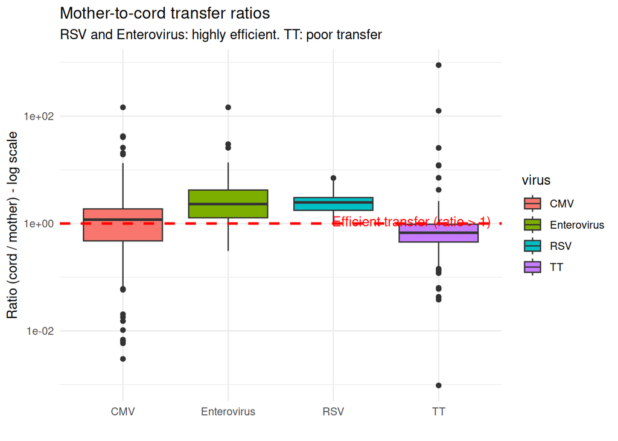

```r
ratios_long <- donnees %>%
  pivot_longer(cols = c("ratio CMV", "ratio RSV", "ratio ENTERO", "ratio TT"),
               names_to = "virus", values_to = "ratio") %>%
  mutate(virus = recode(virus,
                        "ratio CMV" = "CMV",
                        "ratio RSV" = "RSV",
                        "ratio ENTERO" = "Enterovirus",
                        "ratio TT" = "TT"))

ggplot(ratios_long, aes(x = virus, y = ratio, fill = virus)) +
  geom_boxplot() +
  geom_hline(yintercept = 1, linetype = "dashed", color = "red", size = 1) +
  annotate("text", x = 4.5, y = 1.1, label = "Efficient transfer (ratio > 1)",
           color = "red", hjust = 1) +
  scale_y_log10() +
  labs(title = "Mother-to-cord transfer ratios",
       subtitle = "RSV and Enterovirus: highly efficient. TT: poor transfer",
       x = "", y = "Ratio (cord / mother) - log scale") +
  theme_minimal()
```

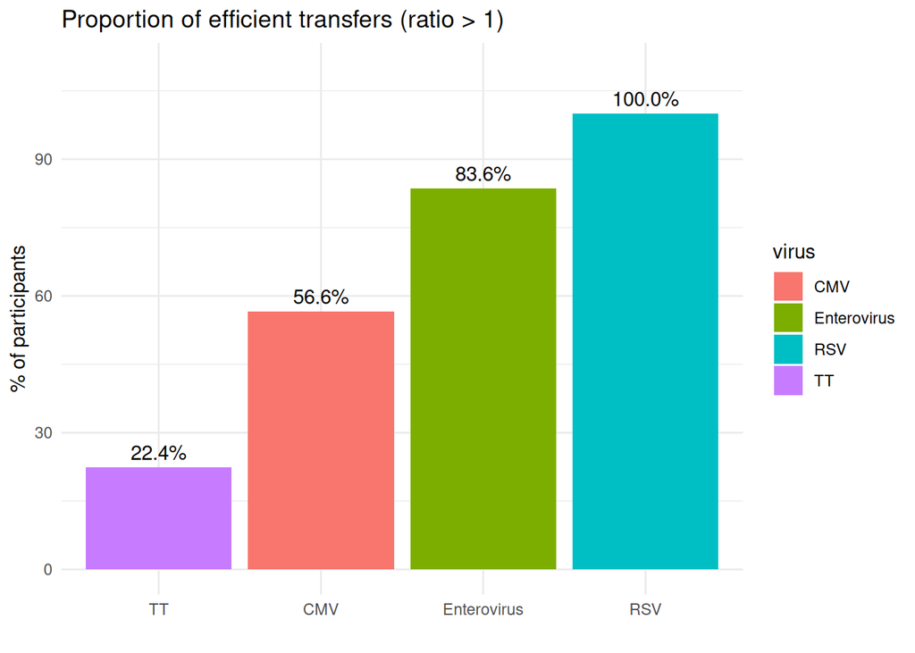

```r
pct <- data.frame(virus = c("CMV", "RSV", "Enterovirus", "TT"),
                  pct = c(56.6, 100, 83.6, 22.4))
ggplot(pct, aes(x = reorder(virus, pct), y = pct, fill = virus)) +
  geom_col() +
  geom_text(aes(label = sprintf("%.1f%%", pct)), vjust = -0.5) +
  labs(title = "Proportion of efficient transfers (ratio > 1)",
       x = "", y = "% of participants") +
  theme_minimal() + ylim(0, 110)
```

### Correlations between ratios

```r
cor(donnees[, c("ratio CMV", "ratio RSV", "ratio ENTERO", "ratio TT")],
    use = "pairwise.complete.obs") %>% round(3)
```

```
##              ratio CMV ratio RSV ratio ENTERO ratio TT
## ratio CMV        1.000     0.055        0.015   -0.018
## ratio RSV        0.055     1.000        0.283    0.056
## ratio ENTERO     0.015     0.283        1.000   -0.001
## ratio TT        -0.018     0.056       -0.001    1.000
```

> **Finding:** **RSV** transfers best (100% of women, median = 2.47), followed by **Enterovirus** (83.6%, median = 2.30). **CMV** is mixed (56.6%, median = 1.18). **TT** transfers poorly (22.4%, median = 0.67). Correlations between ratios are very weak → each virus has its own transfer mechanism.

## 3️⃣ Which factors predict birth weight?

```r
modele <- lm(`Birth weigh (tg)` ~ `Gestestational age of delivery` +
               `child SEX` + `HIV STATUS` +
               `Systolic blood pressure` + `Diastolic blood pressure` +
               `sCD14 [ng/ml]` + `HowmanydeliverieshaveyouhadintotalParity`,
             data = donnees)
summary(modele)
```

```
##
## Call:
## lm(formula = `Birth weigh (tg)` ~ `Gestestational age of delivery` +
##     `child SEX` + `HIV STATUS` + `Systolic blood pressure` +
##     `Diastolic blood pressure` + `sCD14 [ng/ml]` + HowmanydeliverieshaveyouhadintotalParity,
##     data = donnees)
##
## Residuals:
##      Min       1Q   Median       3Q      Max
## -1756.76  -257.21    34.06   245.41  1096.12
##
## Coefficients:
##                                            Estimate Std. Error t value Pr(>|t|)
## (Intercept)                              -4014.8070  1451.5980  -2.766  0.00654
## `Gestestational age of delivery`           177.4984    34.4229   5.156 9.57e-07
## `child SEX`M                                -1.0432    84.2094  -0.012  0.99014
## `HIV STATUS`Positive                        22.9143    91.7486   0.250  0.80319
## `Systolic blood pressure`                    6.4358     2.6728   2.408  0.01750
## `Diastolic blood pressure`                  -8.8066     3.0532  -2.884  0.00462
## `sCD14 [ng/ml]`                              0.1508     0.1807   0.834  0.40560
## HowmanydeliverieshaveyouhadintotalParity   -10.8970    24.0683  -0.453  0.65151
##
## (Intercept)                              **
## `Gestestational age of delivery`         ***
## `child SEX`M
## `HIV STATUS`Positive
## `Systolic blood pressure`                *
## `Diastolic blood pressure`               **
## `sCD14 [ng/ml]`
## HowmanydeliverieshaveyouhadintotalParity
## ---
## Signif. codes:  0 '***' 0.001 '**' 0.01 '*' 0.05 '.' 0.1 ' ' 1
##
## Residual standard error: 474.7 on 125 degrees of freedom
##   (19 observations deleted due to missingness)
## Multiple R-squared:  0.2513, Adjusted R-squared:  0.2094
## F-statistic: 5.993 on 7 and 125 DF,  p-value: 4.951e-06
```

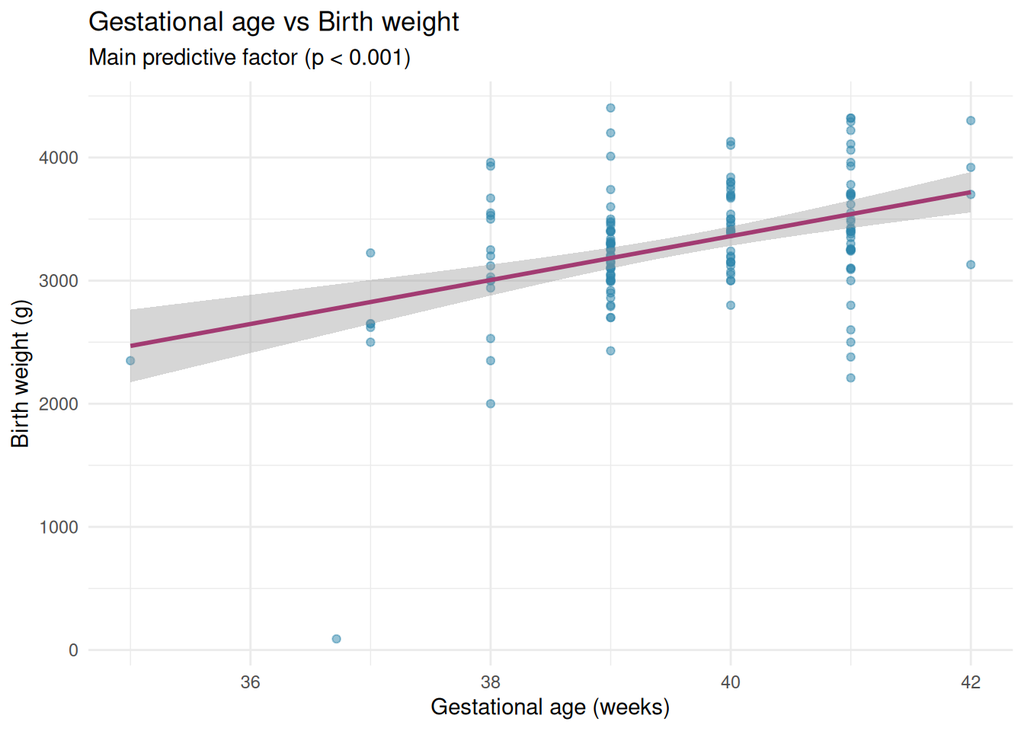

```r
ggplot(donnees, aes(x = `Gestestational age of delivery`, y = `Birth weigh (tg)`)) +
  geom_point(alpha = 0.5, color = "#2E86AB") +
  geom_smooth(method = "lm", color = "#A23B72") +
  labs(title = "Gestational age vs Birth weight",
       subtitle = "Main predictive factor (p < 0.001)",
       x = "Gestational age (weeks)", y = "Birth weight (g)") +
  theme_minimal()
```

> **Finding:** Only 3 significant factors: - **Gestational age** (p < 0.001) — longer pregnancy → heavier baby - **Systolic blood pressure** (p = 0.018) — positive effect - **Diastolic blood pressure** (p = 0.005) — negative effect

> **HIV**, **sex**, **parity** and **sCD14** are not significant. The model explains ~25% of variance (R² = 0.25).

## 4️⃣ Does parity affect antibody transfer?

```r
donnees <- donnees %>%
  mutate(parite_cat = case_when(
    HowmanydeliverieshaveyouhadintotalParity <= 1 ~ "Primiparous",
    HowmanydeliverieshaveyouhadintotalParity <= 3 ~ "Multiparous",
    TRUE ~ "Grand multiparous"
  ))

for (nom in names(virus_ratio)) {
  cat(sprintf("\n=== %s ===\n", virus_ratio[nom]))
  print(donnees %>%
    filter(!is.na(parite_cat)) %>%
    group_by(parite_cat) %>%
    summarise(
      n = n(),
      med_ratio = median(.data[[nom]], na.rm = TRUE),
      prop_efficace = sum(.data[[nom]] > 1, na.rm = TRUE) / sum(!is.na(.data[[nom]])) * 100
    ))
}
```

```
##
## === CMV ===
## # A tibble: 3 × 4
##   parite_cat            n med_ratio prop_efficace
##   <chr>             <int>     <dbl>         <dbl>
## 1 Grand multiparous    32      1.23          62.5
## 2 Multiparous          61      1.12          52.5
## 3 Primiparous          59      1.17          57.6
##
## === RSV ===
## # A tibble: 3 × 4
##   parite_cat            n med_ratio prop_efficace
##   <chr>             <int>     <dbl>         <dbl>
## 1 Grand multiparous    32      2.26           100
## 2 Multiparous          61      2.31           100
## 3 Primiparous          59      2.79           100
##
## === Enterovirus ===
## # A tibble: 3 × 4
##   parite_cat            n med_ratio prop_efficace
##   <chr>             <int>     <dbl>         <dbl>
## 1 Grand multiparous    32      2.42          78.1
## 2 Multiparous          61      2.12          85.2
## 3 Primiparous          59      2.54          84.7
##
## === TT ===
## # A tibble: 3 × 4
##   parite_cat            n med_ratio prop_efficace
##   <chr>             <int>     <dbl>         <dbl>
## 1 Grand multiparous    32     0.687          18.8
## 2 Multiparous          61     0.658          19.7
## 3 Primiparous          59     0.722          27.1
```

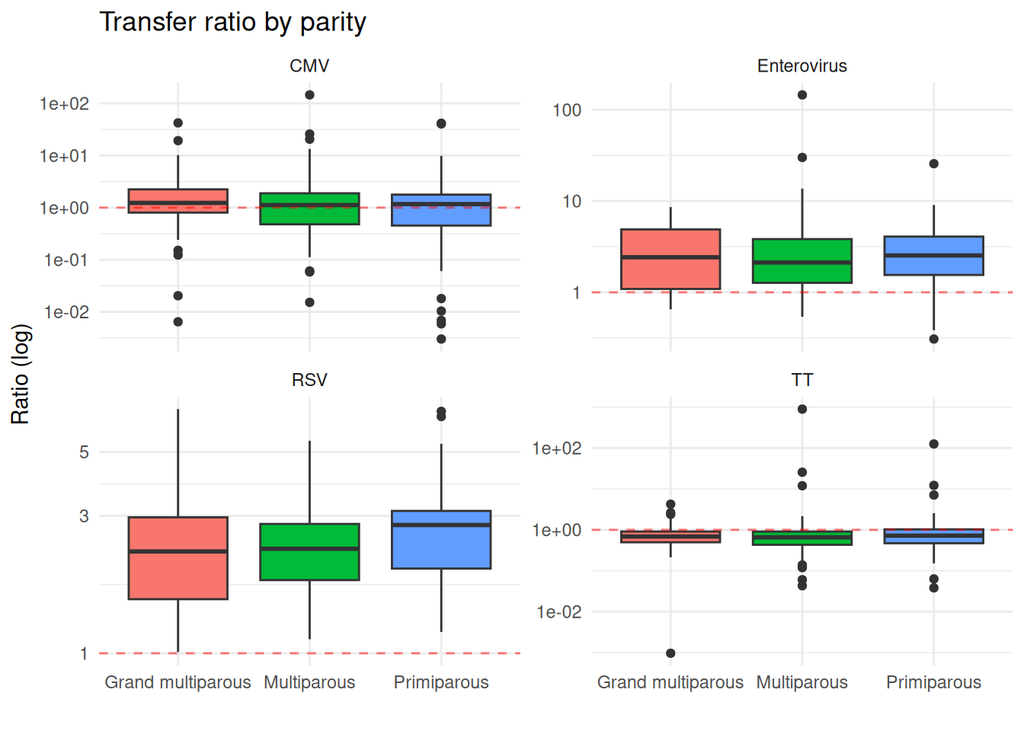

```r
ratios_long <- donnees %>%
  pivot_longer(cols = c("ratio CMV", "ratio RSV", "ratio ENTERO", "ratio TT"),
               names_to = "virus", values_to = "ratio") %>%
  mutate(virus = recode(virus,
                        "ratio CMV" = "CMV",
                        "ratio RSV" = "RSV",
                        "ratio ENTERO" = "Enterovirus",
                        "ratio TT" = "TT"))

ggplot(ratios_long %>% filter(!is.na(parite_cat)),
       aes(x = parite_cat, y = ratio, fill = parite_cat)) +
  geom_boxplot() +
  geom_hline(yintercept = 1, linetype = "dashed", color = "red", alpha = 0.5) +
  facet_wrap(~virus, scales = "free_y") +
  scale_y_log10() +
  labs(title = "Transfer ratio by parity",
       x = "", y = "Ratio (log)") +
  theme_minimal() + theme(legend.position = "none")
```

> **Finding:** Parity has **little effect** on transfer. Primiparous women may transfer **RSV** slightly better (median = 2.79 vs 2.26-2.31). For other viruses, differences are minimal.

## 5️⃣ Does birth weight affect antibody transfer?

```r
donnees <- donnees %>%
  mutate(poids_cat = case_when(
    `Birth weigh (tg)` < 2500 ~ "Low birth weight (< 2.5kg)",
    `Birth weigh (tg)` <= 4000 ~ "Normal (2.5-4kg)",
    TRUE ~ "Macrosomic (> 4kg)"
  ))

for (nom in names(virus_ratio)) {
  c <- cor(donnees[["Birth weigh (tg)"]], donnees[[nom]], use = "complete.obs")
  cat(sprintf("%s vs Birth weight : r = %.3f\n", virus_ratio[nom], c))
}
```

```
## CMV vs Birth weight : r = 0.028
## RSV vs Birth weight : r = -0.017
## Enterovirus vs Birth weight : r = -0.088
## TT vs Birth weight : r = 0.048
```

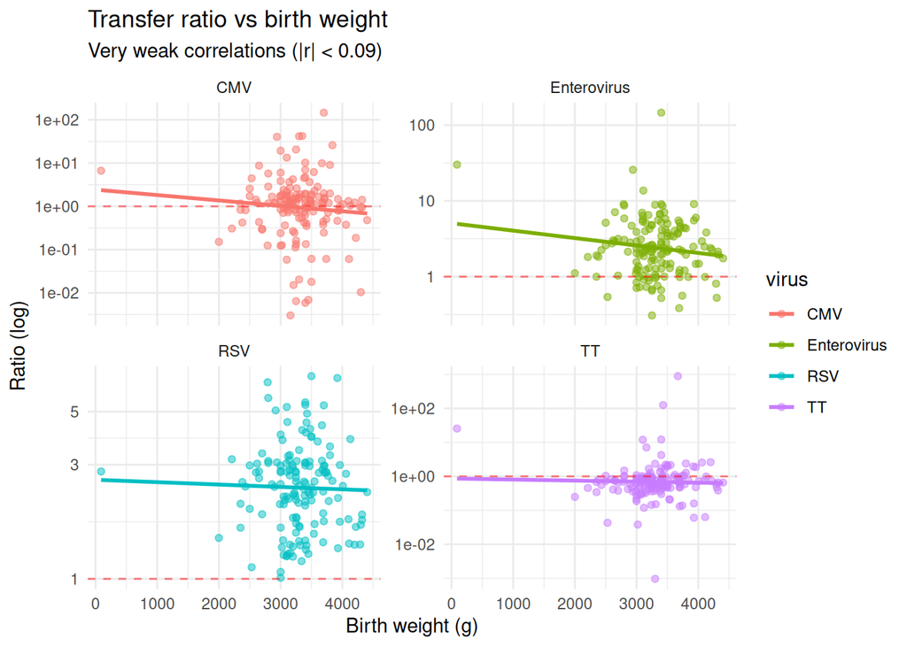

```r
ggplot(ratios_long, aes(x = `Birth weigh (tg)`, y = ratio, color = virus)) +
  geom_point(alpha = 0.5) +
  geom_hline(yintercept = 1, linetype = "dashed", color = "red", alpha = 0.5) +
  geom_smooth(method = "lm", se = FALSE) +
  facet_wrap(~virus, scales = "free_y") +
  scale_y_log10() +
  labs(title = "Transfer ratio vs birth weight",
       subtitle = "Very weak correlations (|r| < 0.09)",
       x = "Birth weight (g)", y = "Ratio (log)") +
  theme_minimal()
```

> **Finding:** No significant correlation between **birth weight** and **transfer ratios** (|r| < 0.09 for all). Antibody transfer appears independent of child weight.

## 6️⃣ Global correlations

```r
vars <- c("ratio CMV", "ratio RSV", "ratio ENTERO", "ratio TT",
          "Birth weigh (tg)", "Gestestational age of delivery",
          "sCD14 [ng/ml]", "IFABP [pg/ml]",
          "HowmanydeliverieshaveyouhadintotalParity")
cor(donnees[, vars], use = "pairwise.complete.obs") %>% round(3)
```

```
##                                          ratio CMV ratio RSV ratio ENTERO
## ratio CMV                                    1.000     0.055        0.015
## ratio RSV                                    0.055     1.000        0.283
## ratio ENTERO                                 0.015     0.283        1.000
## ratio TT                                    -0.018     0.056       -0.001
## Birth weigh (tg)                             0.028    -0.017       -0.088
## Gestestational age of delivery               0.058     0.146        0.056
## sCD14 [ng/ml]                               -0.002     0.002       -0.041
## IFABP [pg/ml]                                0.018     0.010        0.173
## HowmanydeliverieshaveyouhadintotalParity     0.062    -0.098        0.029
##                                          ratio TT Birth weigh (tg)
## ratio CMV                                  -0.018            0.028
## ratio RSV                                   0.056           -0.017
## ratio ENTERO                               -0.001           -0.088
## ratio TT                                    1.000            0.048
## Birth weigh (tg)                            0.048            1.000
## Gestestational age of delivery              0.030            0.424
## sCD14 [ng/ml]                               0.028            0.068
## IFABP [pg/ml]                               0.019           -0.505
## HowmanydeliverieshaveyouhadintotalParity   -0.023           -0.089
##                                          Gestestational age of delivery
## ratio CMV                                                         0.058
## ratio RSV                                                         0.146
## ratio ENTERO                                                      0.056
## ratio TT                                                          0.030
## Birth weigh (tg)                                                  0.424
## Gestestational age of delivery                                    1.000
## sCD14 [ng/ml]                                                    -0.093
## IFABP [pg/ml]                                                    -0.194
## HowmanydeliverieshaveyouhadintotalParity                         -0.120
##                                          sCD14 [ng/ml] IFABP [pg/ml]
## ratio CMV                                       -0.002         0.018
## ratio RSV                                        0.002         0.010
## ratio ENTERO                                    -0.041         0.173
## ratio TT                                         0.028         0.019
## Birth weigh (tg)                                 0.068        -0.505
## Gestestational age of delivery                  -0.093        -0.194
## sCD14 [ng/ml]                                    1.000        -0.032
## IFABP [pg/ml]                                   -0.032         1.000
## HowmanydeliverieshaveyouhadintotalParity         0.151         0.041
##                                          HowmanydeliverieshaveyouhadintotalParity
## ratio CMV                                                                   0.062
## ratio RSV                                                                  -0.098
## ratio ENTERO                                                                0.029
## ratio TT                                                                   -0.023
## Birth weigh (tg)                                                           -0.089
## Gestestational age of delivery                                             -0.120
## sCD14 [ng/ml]                                                               0.151
## IFABP [pg/ml]                                                               0.041
## HowmanydeliverieshaveyouhadintotalParity                                    1.000
```

### Ratio by HIV status

```r
for (nom in names(virus_ratio)) {
  res <- donnees %>%
    group_by(`HIV STATUS`) %>%
    summarise(med = median(.data[[nom]], na.rm = TRUE))
  cat(sprintf("%s : HIV- = %.3f, HIV+ = %.3f\n", virus_ratio[nom], res$med[1], res$med[2]))
}
```

```
## CMV : HIV- = 1.179, HIV+ = 1.181
## RSV : HIV- = 2.527, HIV+ = 2.419
## Enterovirus : HIV- = 2.393, HIV+ = 2.282
## TT : HIV- = 0.756, HIV+ = 0.575
```

## 7️⃣ Deep dive: child sex as the main factor

Re-analyzing everything with **sex (F/M)** as the grouping factor, **stratified by HIV status**.

### 7.1 Transfer ratios — sex × HIV

```r
donnees <- donnees %>%
  mutate(parite_cat = case_when(
    HowmanydeliverieshaveyouhadintotalParity <= 1 ~ "Primiparous",
    HowmanydeliverieshaveyouhadintotalParity <= 3 ~ "Multiparous",
    TRUE ~ "Grand multiparous"))
```

```r
for (hiv_statut in c("Negative", "Positive")) {
  cat(sprintf("\n━━━ HIV %s ━━━\n", hiv_statut))
  sous <- donnees %>% filter(`HIV STATUS` == hiv_statut)

  virus_ratio <- c("ratio CMV" = "CMV", "ratio RSV" = "RSV",
                   "ratio ENTERO" = "Enterovirus", "ratio TT" = "TT")

  for (nom in names(virus_ratio)) {
    cat(sprintf("\n◆ %s\n", virus_ratio[nom]))
    res <- sous %>%
      filter(!is.na(`child SEX`)) %>%
      group_by(`child SEX`) %>%
      summarise(
        n = n(),
        med = median(.data[[nom]], na.rm = TRUE),
        pct_efficace = round(100 * sum(.data[[nom]] > 1, na.rm = TRUE) / sum(!is.na(.data[[nom]])), 1)
      )
    print(res)
  }
}
```

```
##
## ━━━ HIV Negative ━━━
##
## ◆ CMV
## # A tibble: 2 × 4
##   `child SEX`     n   med pct_efficace
##   <chr>       <int> <dbl>        <dbl>
## 1 F              39 0.821         43.6
## 2 M              34 1.53          70.6
##
## ◆ RSV
## # A tibble: 2 × 4
##   `child SEX`     n   med pct_efficace
##   <chr>       <int> <dbl>        <dbl>
## 1 F              39  2.46          100
## 2 M              34  2.53          100
##
## ◆ Enterovirus
## # A tibble: 2 × 4
##   `child SEX`     n   med pct_efficace
##   <chr>       <int> <dbl>        <dbl>
## 1 F              39  2.26         84.6
## 2 M              34  2.28         79.4
##
## ◆ TT
## # A tibble: 2 × 4
##   `child SEX`     n   med pct_efficace
##   <chr>       <int> <dbl>        <dbl>
## 1 F              39 0.626         17.9
## 2 M              34 0.911         38.2
##
## ━━━ HIV Positive ━━━
##
## ◆ CMV
## # A tibble: 2 × 4
##   `child SEX`     n   med pct_efficace
##   <chr>       <int> <dbl>        <dbl>
## 1 F              36 1.28          66.7
## 2 M              29 0.853         48.3
##
## ◆ RSV
## # A tibble: 2 × 4
##   `child SEX`     n   med pct_efficace
##   <chr>       <int> <dbl>        <dbl>
## 1 F              36  2.50          100
## 2 M              29  2.29          100
##
## ◆ Enterovirus
## # A tibble: 2 × 4
##   `child SEX`     n   med pct_efficace
##   <chr>       <int> <dbl>        <dbl>
## 1 F              36  2.51         86.1
## 2 M              29  1.95         82.8
##
## ◆ TT
## # A tibble: 2 × 4
##   `child SEX`     n   med pct_efficace
##   <chr>       <int> <dbl>        <dbl>
## 1 F              36 0.625         16.7
## 2 M              29 0.570         13.8
```

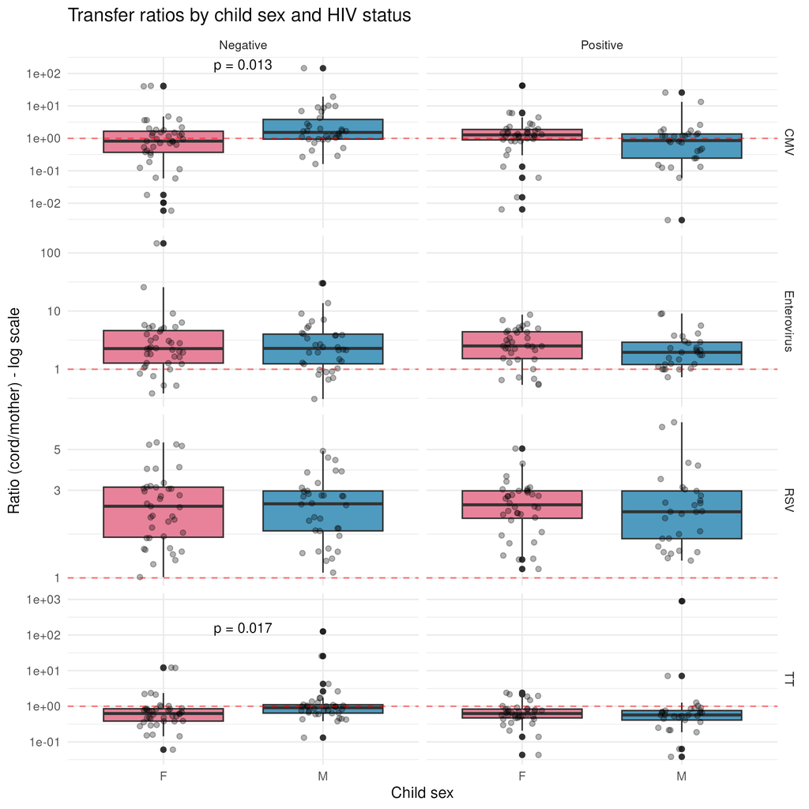

Transfer ratios by child sex and HIV

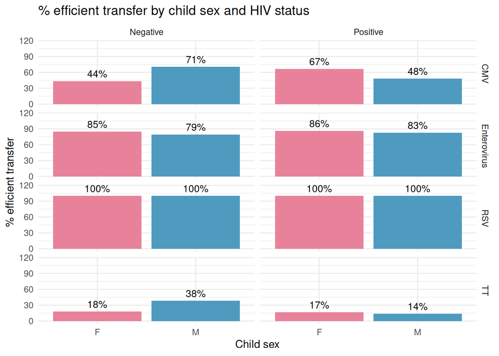

```r
# % efficient transfer
pct_data <- donnees %>%
  filter(!is.na(`child SEX`)) %>%
  pivot_longer(cols = c("ratio CMV", "ratio RSV", "ratio ENTERO", "ratio TT"),
               names_to = "virus", values_to = "ratio") %>%
  mutate(virus = recode(virus, "ratio CMV" = "CMV", "ratio RSV" = "RSV",
                        "ratio ENTERO" = "Enterovirus", "ratio TT" = "TT")) %>%
  group_by(`HIV STATUS`, `child SEX`, virus) %>%
  summarise(
    n_total = sum(!is.na(ratio)),
    n_efficace = sum(ratio > 1, na.rm = TRUE),
    pct = 100 * n_efficace / n_total,
    .groups = "drop")

ggplot(pct_data, aes(x = `child SEX`, y = pct, fill = `child SEX`)) +
  geom_col() +
  geom_text(aes(label = sprintf("%.0f%%", pct)), vjust = -0.5, size = 3.5) +
  facet_grid(virus ~ `HIV STATUS`) +
  scale_fill_manual(values = c("F" = "#E8829A", "M" = "#4E9BBF")) +
  ylim(0, 115) +
  labs(title = "% efficient transfer by child sex and HIV status",
       x = "Child sex", y = "% efficient transfer") +
  theme_minimal() + theme(legend.position = "none")
```

> **Key finding:** In **HIV-** mothers, **boys** receive **CMV** better (70.6% vs 43.6% for girls, p = 0.013) and **TT** (38.2% vs 17.9%, p = 0.017). In **HIV+** mothers, the opposite: **girls** receive **CMV** better (66.7% vs 48.3%, p = 0.06 — trend).

### 7.2 Inflammation markers — sex × HIV

```r
for (hiv_statut in c("Negative", "Positive")) {
  cat(sprintf("\n━━━ HIV %s ━━━\n", hiv_statut))
  sous <- donnees %>% filter(`HIV STATUS` == hiv_statut)

  for (m in c("sCD14 [ng/ml]", "IFABP [pg/ml]", "cord sCD14 [ng/ml]")) {
    cat(sprintf("\n◆ %s\n", m))
    res <- sous %>%
      filter(!is.na(`child SEX`)) %>%
      group_by(`child SEX`) %>%
      summarise(
        n = n(),
        med = median(.data[[m]], na.rm = TRUE),
        moy = mean(.data[[m]], na.rm = TRUE)
      )
    print(res)
  }
}
```

```
##
## ━━━ HIV Negative ━━━
##
## ◆ sCD14 [ng/ml]
## # A tibble: 2 × 4
##   `child SEX`     n   med   moy
##   <chr>       <int> <dbl> <dbl>
## 1 F              39 1106. 1086.
## 2 M              34 1125. 1105.
##
## ◆ IFABP [pg/ml]
## # A tibble: 2 × 4
##   `child SEX`     n   med    moy
##   <chr>       <int> <dbl>  <dbl>
## 1 F              39  793.  1043.
## 2 M              34  758. 24818.
##
## ◆ cord sCD14 [ng/ml]
## # A tibble: 2 × 4
##   `child SEX`     n   med   moy
##   <chr>       <int> <dbl> <dbl>
## 1 F              39  53.1  54.1
## 2 M              34  41.4  75.9
##
## ━━━ HIV Positive ━━━
##
## ◆ sCD14 [ng/ml]
## # A tibble: 2 × 4
##   `child SEX`     n   med   moy
##   <chr>       <int> <dbl> <dbl>
## 1 F              36 1310. 1322.
## 2 M              29 1291. 1278.
##
## ◆ IFABP [pg/ml]
## # A tibble: 2 × 4
##   `child SEX`     n   med   moy
##   <chr>       <int> <dbl> <dbl>
## 1 F              36 1011. 1719.
## 2 M              29 1153. 1363.
##
## ◆ cord sCD14 [ng/ml]
## # A tibble: 2 × 4
##   `child SEX`     n   med   moy
##   <chr>       <int> <dbl> <dbl>
## 1 F              36  46.2  50.5
## 2 M              29  44.9  52.9
```

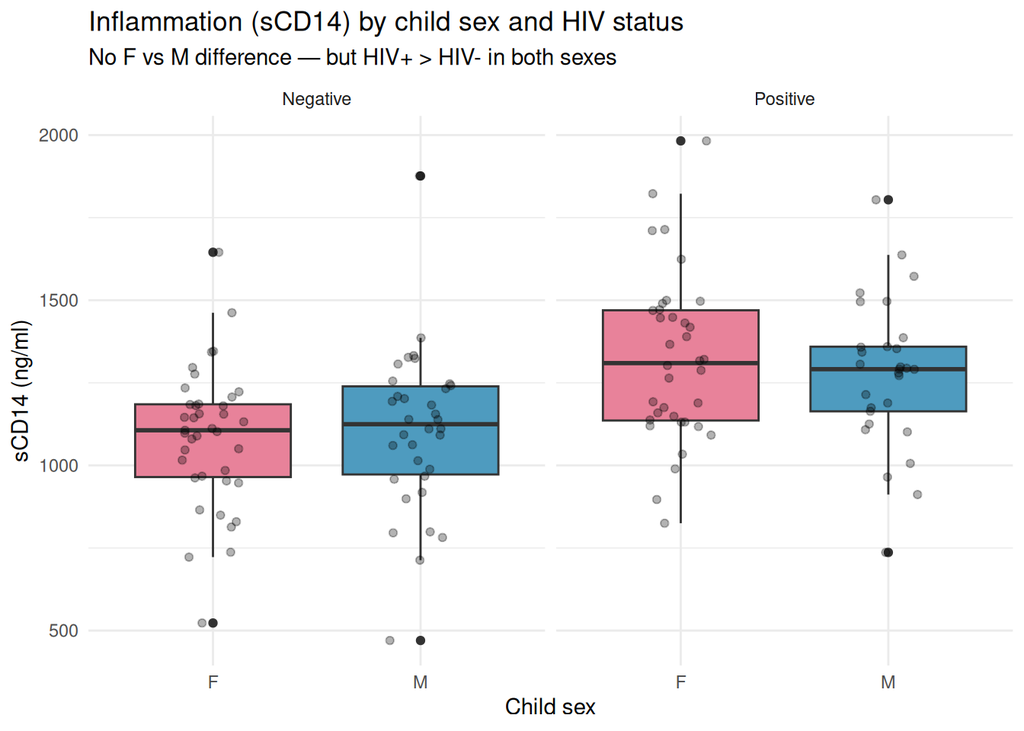

```r
ggplot(donnees %>% filter(!is.na(`child SEX`)),
       aes(x = `child SEX`, y = `sCD14 [ng/ml]`, fill = `child SEX`)) +
  geom_boxplot() +
  geom_jitter(alpha = 0.3, width = 0.15) +
  facet_wrap(~`HIV STATUS`) +
  scale_fill_manual(values = c("F" = "#E8829A", "M" = "#4E9BBF")) +
  labs(title = "Inflammation (sCD14) by child sex and HIV status",
       subtitle = "No F vs M difference — but HIV+ > HIV- in both sexes",
       x = "Child sex", y = "sCD14 (ng/ml)") +
  theme_minimal() + theme(legend.position = "none")
```

### 7.3 Socio-demographic factors — sex × HIV

```r
for (hiv_statut in c("Negative", "Positive")) {
  cat(sprintf("\n━━━ HIV %s ━━━\n", hiv_statut))
  sous <- donnees %>% filter(`HIV STATUS` == hiv_statut)

  cat("\n◆ Birth weight (g)\n")
  res <- sous %>%
    filter(!is.na(`child SEX`)) %>%
    group_by(`child SEX`) %>%
    summarise(med = median(`Birth weigh (tg)`, na.rm = TRUE),
              moy = mean(`Birth weigh (tg)`, na.rm = TRUE))
  print(res)

  cat("\n◆ Gestational age\n")
  res <- sous %>%
    filter(!is.na(`child SEX`)) %>%
    group_by(`child SEX`) %>%
    summarise(med = median(`Gestestational age of delivery`, na.rm = TRUE),
              moy = mean(`Gestestational age of delivery`, na.rm = TRUE))
  print(res)

  cat("\n◆ Parity (number of deliveries)\n")
  res <- sous %>%
    filter(!is.na(`child SEX`)) %>%
    group_by(`child SEX`) %>%
    summarise(med = median(HowmanydeliverieshaveyouhadintotalParity, na.rm = TRUE),
              moy = mean(HowmanydeliverieshaveyouhadintotalParity, na.rm = TRUE))
  print(res)
}
```

```
##
## ━━━ HIV Negative ━━━
##
## ◆ Birth weight (g)
## # A tibble: 2 × 3
##   `child SEX`   med   moy
##   <chr>       <dbl> <dbl>
## 1 F            3300 3334.
## 2 M            3390 3294.
##
## ◆ Gestational age
## # A tibble: 2 × 3
##   `child SEX`   med   moy
##   <chr>       <dbl> <dbl>
## 1 F            40    40.1
## 2 M            39.5  39.5
##
## ◆ Parity (number of deliveries)
## # A tibble: 2 × 3
##   `child SEX`   med   moy
##   <chr>       <dbl> <dbl>
## 1 F               1  1.63
## 2 M               2  2.18
##
## ━━━ HIV Positive ━━━
##
## ◆ Birth weight (g)
## # A tibble: 2 × 3
##   `child SEX`   med   moy
##   <chr>       <dbl> <dbl>
## 1 F            3300 3285.
## 2 M            3260 3263.
##
## ◆ Gestational age
## # A tibble: 2 × 3
##   `child SEX`   med   moy
##   <chr>       <dbl> <dbl>
## 1 F              39  39.5
## 2 M              39  39.3
##
## ◆ Parity (number of deliveries)
## # A tibble: 2 × 3
##   `child SEX`   med   moy
##   <chr>       <dbl> <dbl>
## 1 F             2.5  2.64
## 2 M             2    2.34
```

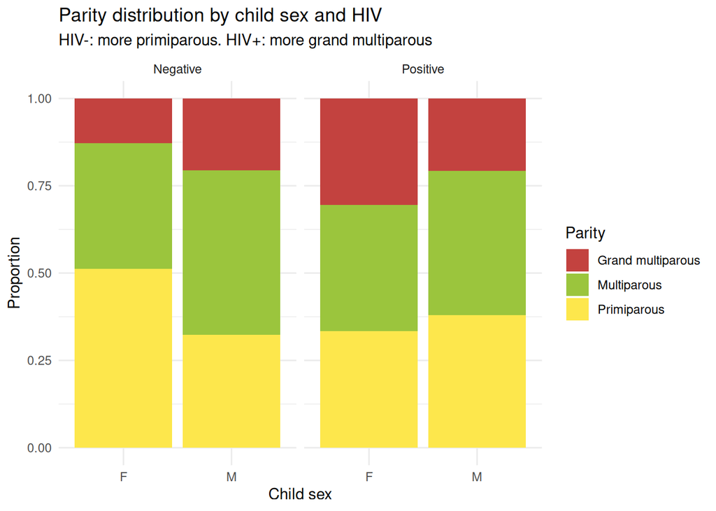

```r
ggplot(donnees %>% filter(!is.na(`child SEX`)),
       aes(x = `child SEX`, fill = parite_cat)) +
  geom_bar(position = "fill") +
  facet_wrap(~`HIV STATUS`) +
  scale_fill_manual(values = c("Primiparous" = "#FDE74C", "Multiparous" = "#9BC53D",
                                "Grand multiparous" = "#C3423F")) +
  labs(title = "Parity distribution by child sex and HIV",
       subtitle = "HIV-: more primiparous. HIV+: more grand multiparous",
       x = "Child sex", y = "Proportion", fill = "Parity") +
  theme_minimal()
```

### 7.4 Maternal viral loads — sex × HIV

```r
for (hiv_statut in c("Negative", "Positive")) {
  cat(sprintf("\n━━━ HIV %s ━━━\n", hiv_statut))
  sous <- donnees %>% filter(`HIV STATUS` == hiv_statut)

  for (nm in c("CMV mother", "RSV mother", "Enterovirus mother", "TT mother")) {
    cat(sprintf("\n◆ %s\n", nm))
    res <- sous %>%
      filter(!is.na(`child SEX`)) %>%
      group_by(`child SEX`) %>%
      summarise(med = median(.data[[nm]], na.rm = TRUE))
    print(res)
  }
}
```

```
##
## ━━━ HIV Negative ━━━
##
## ◆ CMV mother
## # A tibble: 2 × 2
##   `child SEX`      med
##   <chr>          <dbl>
## 1 F           1322622.
## 2 M            809107
##
## ◆ RSV mother
## # A tibble: 2 × 2
##   `child SEX`      med
##   <chr>          <dbl>
## 1 F           3694088
## 2 M           4090340.
##
## ◆ Enterovirus mother
## # A tibble: 2 × 2
##   `child SEX`      med
##   <chr>          <dbl>
## 1 F           1982618.
## 2 M           2380687.
##
## ◆ TT mother
## # A tibble: 2 × 2
##   `child SEX`      med
##   <chr>          <dbl>
## 1 F           1691748.
## 2 M           1592632
##
## ━━━ HIV Positive ━━━
##
## ◆ CMV mother
## # A tibble: 2 × 2
##   `child SEX`      med
##   <chr>          <dbl>
## 1 F           2668402.
## 2 M           1202731
##
## ◆ RSV mother
## # A tibble: 2 × 2
##   `child SEX`      med
##   <chr>          <dbl>
## 1 F           3546669.
## 2 M           4199508.
##
## ◆ Enterovirus mother
## # A tibble: 2 × 2
##   `child SEX`      med
##   <chr>          <dbl>
## 1 F           1650435.
## 2 M           2389258.
##
## ◆ TT mother
## # A tibble: 2 × 2
##   `child SEX`      med
##   <chr>          <dbl>
## 1 F           1307590.
## 2 M           1357488.
```

### 🎯 Summary: what sex reveals

[output not shown]

## 📋 Summary table

| Question | Answer |
| --- | --- |
| HIV → more inflammation? | **Yes** — sCD14 higher (p < 0.001) |
| HIV → intestinal damage? | **Yes** — IFABP higher (p = 0.006) |
| Best transferred antibody? | **RSV** (100%, median = 2.47) then **Enterovirus** (84%, med = 2.30) |
| Worst transferred? | **TT** (22%, median = 0.67) |
| Does parity affect transfer? | **Very little** — slight advantage for primiparous for RSV |
| Does birth weight affect transfer? | **No** — near-zero correlations |
| What predicts birth weight? | **Gestational age** (+++), systolic/diastolic blood pressure |

## 8️⃣ Correlation matrices by child sex and HIV status

Correlation heatmaps for **23 markers** (viral loads, transfer ratios, inflammation markers, clinical measurements).

### Combined view (2×2)

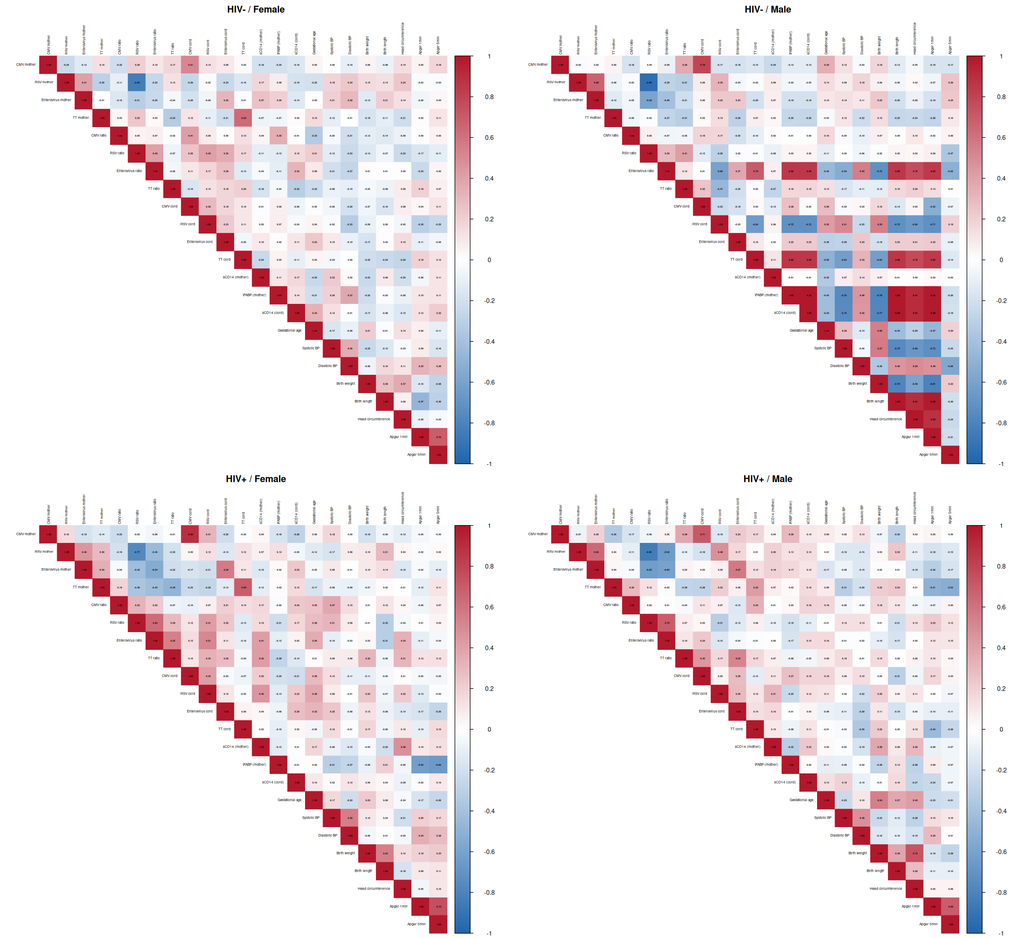

Correlation matrix by sex and HIV